# hydroSWOT anomalies

Mark Hagemann

November 2, 2016

```
## [[1]]
## [1] "bstats"
```

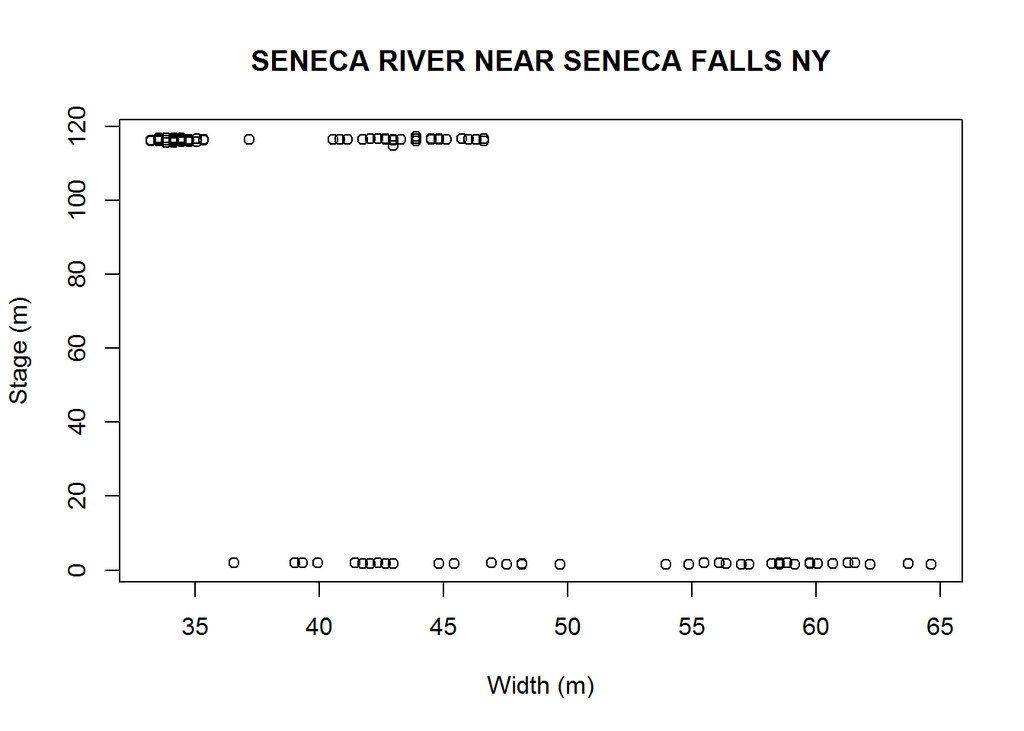

```r
plothw(4232730)
```

Clearly there’s some change in datum going on. Digging deeper, I calculated the range in reported stage for each station. Here are the 40 stations with the largest ranges.

```r
hswot %>%
  group_by(site_no) %>%
  summarize(hrange = max(stage_va) - min(stage_va), n = n()) %>%
  arrange(desc(hrange)) %>%
  head(n = 40L) %>%
  kable()
```

| site_no | hrange | n |
| --- | --- | --- |
| 4240503 | 90937.80 | 295 |
| 7263605 | 8094.00 | 49 |
| 1047150 | 4666.39 | 37 |
| 11359120 | 2990.19 | 3 |
| 5400760 | 980.69 | 19 |
| 5458150 | 922.90 | 2 |
| 5063000 | 891.70 | 11 |
| 5464090 | 794.92 | 2 |
| 5464302 | 784.87 | 2 |
| 4231600 | 503.31 | 97 |
| 7178645 | 500.57 | 24 |
| 13022500 | 389.38 | 46 |
| 4237555 | 303.37 | 149 |
| 4240508 | 303.31 | 85 |
| 5128000 | 300.83 | 7 |
| 8068400 | 131.70 | 11 |
| 8068390 | 130.13 | 13 |
| 2197000 | 116.51 | 76 |
| 15056500 | 111.97 | 9 |
| 1389802 | 111.61 | 4 |
| 8068740 | 111.57 | 9 |
| 8068325 | 111.17 | 10 |
| 8072730 | 107.45 | 5 |
| 8068000 | 101.81 | 16 |
| 8068800 | 98.07 | 13 |
| 1104453 | 96.26 | 3 |
| 8072760 | 93.79 | 6 |
| 8068900 | 89.18 | 17 |
| 8068500 | 80.67 | 25 |
| 8072300 | 80.16 | 8 |
| 2238000 | 61.24 | 34 |
| 8069000 | 60.78 | 12 |
| 6090000 | 58.21 | 6 |
| 7288800 | 56.94 | 89 |
| 9529300 | 56.76 | 122 |
| 7056700 | 51.06 | 39 |
| 8181500 | 50.88 | 13 |
| 5059715 | 50.75 | 33 |
| 3294500 | 50.66 | 18 |
| 7170500 | 50.09 | 39 |

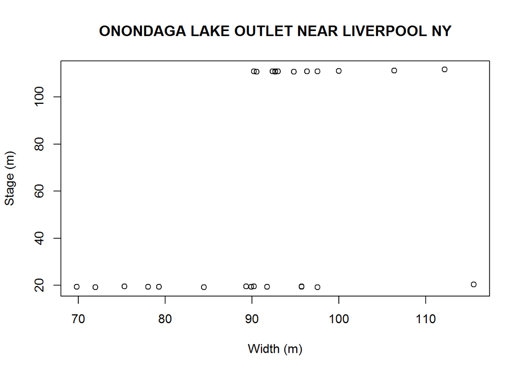

```r
plothw(4240503)
```

I’ll chalk that up to a data entry error. Here’s what it looks like without that value:

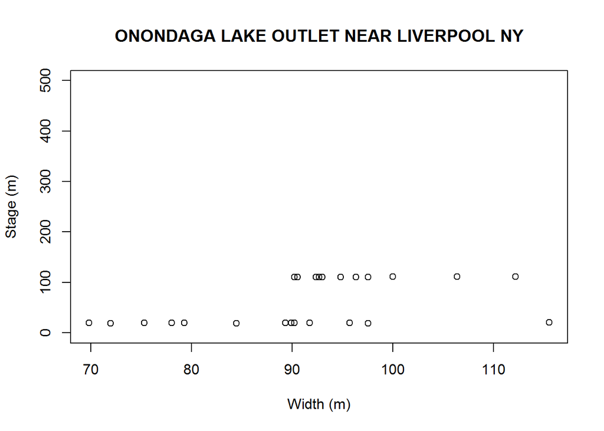

```r
plothw(4240503, ylim = c(0, 500))
```

Still has an apparent change in datum, so removing the obvious outliler did not result in a reliable dataset.

Clearly the worst offenders according to the above table need to be fixed, but this detection approach using the range breaks down further down the list. Consider rows 34 and 35 in the table.

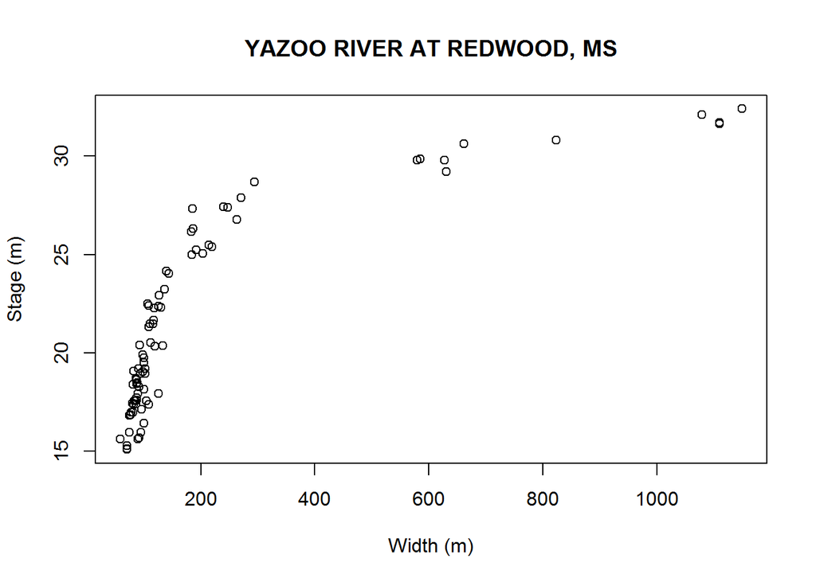

```r
plothw(7288800)
```

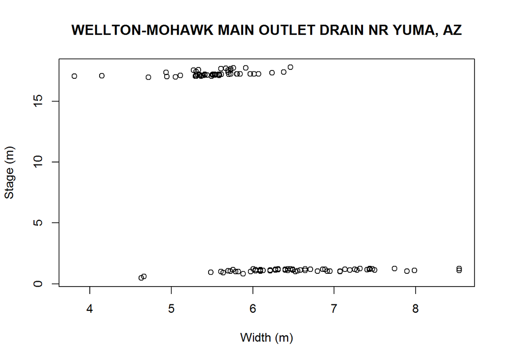

```r
plothw(9529300)
```

Both have about the same range in reported stage, but only one is obviously problematic. Something more sophisticated has to be applied, but with over 10000 stations’ data to look at, it needs to be an automated process.

### The solution

I’m trying an R package produced by Twitter called BreakoutDetection.

```r
devtools::install_github("twitter/BreakoutDetection")
library(BreakoutDetection)

breakout(filter(hswot, site_no == 9529300)$stage_va,
         method = "amoc", plot = TRUE, nperm = 500)
breakout(filter(hswot, site_no == 7288800)$stage_va,
         method = "amoc", plot = TRUE, nperm = 500)
```

Apply this to every station

```r
brstat <- function(x, nperm = 500, ...) {
  br <- breakout(x, nperm = nperm, ...)
  out <- br$stat
  out
}

bstats <- hswot %>%
  filter(!is.na(stage_va)) %>%
  group_by(site_no, station_nm) %>%
  mutate(n = n()) %>%
  arrange(datetime) %>%
  ungroup() %>%
  filter(n > 20) %>%
  group_by(site_no, station_nm) %>%
  summarize(brstat = brstat(stage_va)) %>%
  ungroup() %>%
  mutate(site_no = as.character(site_no))

head(bstats)

summary(bstats$brstat)
```

```r
bstats %>%
  ungroup() %>%
  mutate(site_no = as.character(site_no)) %>%
  arrange(desc(brstat)) %>%
  head(40) %>%
  kable()
```

[output not shown]

The one with the largest statistic looks like this:

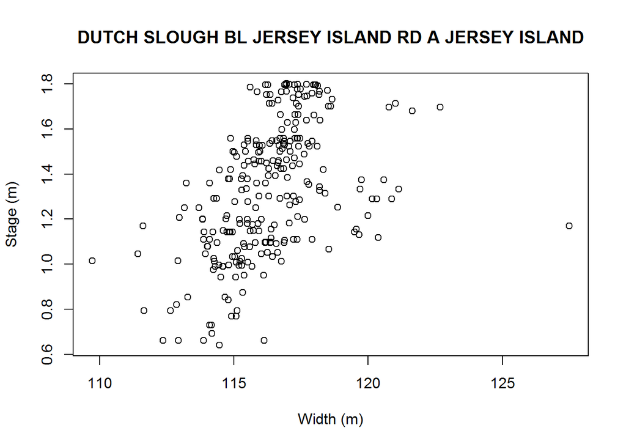

```r
plothw(11313433)
```

I agree that this looks anomalous, and for more than just having a breakpoint. Note that it has a relatively small stage range, and the initial detection method wouldn’t have been much help here.

```r
plothw(arrange(bstats, desc(brstat))$site_no[i])

i <- i + 1
```

I should check on these high-frequency parts. Here’s Harney River near Flamingo FL:

```r
hs1 <- hswot %>%
  filter(site_no == 252551081050900,
         datetime < "2005-01-01") %>%
   transmute(datetime = datetime,
             q_m3s = q_va * 0.028317,
            w_m = stream_wdth_va / 3.28084,
            logQ = log(q_m3s),
            logW = log(w_m),
            h = stage_va,
            xs = site_no,
            xsname = station_nm)
hs1 %>% print(n = 29)
```

```
## # A tibble: 28 × 8
##               datetime      q_m3s   w_m         logQ  logW     h
##                 <dttm>      <dbl> <dbl>        <dbl> <dbl> <dbl>
## 1  2004-02-05 09:47:00 136.233087    NA  4.914367294    NA -3.08
## 2  2004-02-05 09:56:00 131.192661    NA  4.876666937    NA -3.11
## 3  2004-02-05 10:07:00 129.153837    NA  4.861004229    NA -3.15
## 4  2004-02-05 10:16:00 131.249295    NA  4.877098530    NA -3.17
## 5  2004-02-05 10:23:00 130.229883    NA  4.869301220    NA -3.20
## 6  2004-02-05 10:33:00 126.945111    NA  4.843754796    NA -3.22
## 7  2004-02-05 10:41:00 121.848051    NA  4.802774785    NA -3.22
## 8  2004-02-05 10:53:00 111.399078    NA  4.713119051    NA -3.19
## 9  2004-02-05 10:58:00 106.783407    NA  4.670802549    NA -3.14
## 10 2004-02-05 11:03:00  99.024549    NA  4.595367789    NA -3.08
## 11 2004-02-05 11:11:00  86.508435    NA  4.460241924    NA -3.00
## 12 2004-02-05 11:18:00  71.500425    NA  4.269703394    NA -2.85
```

[output cut: 17 more lines]

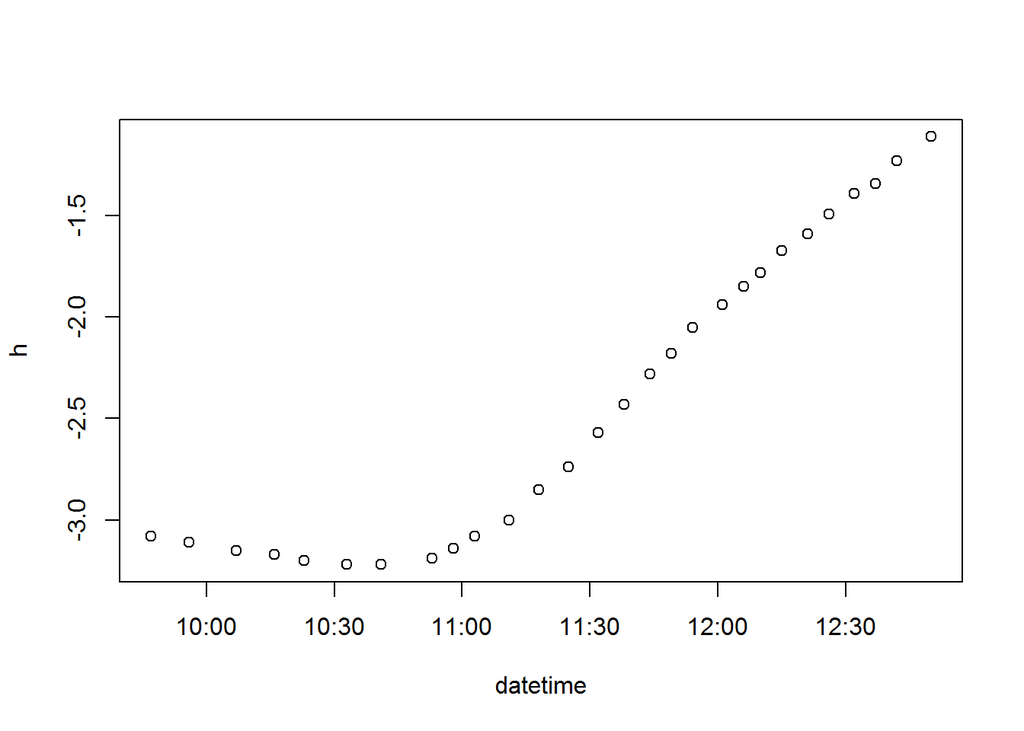

```r
plot(h ~ datetime, hs1)
```

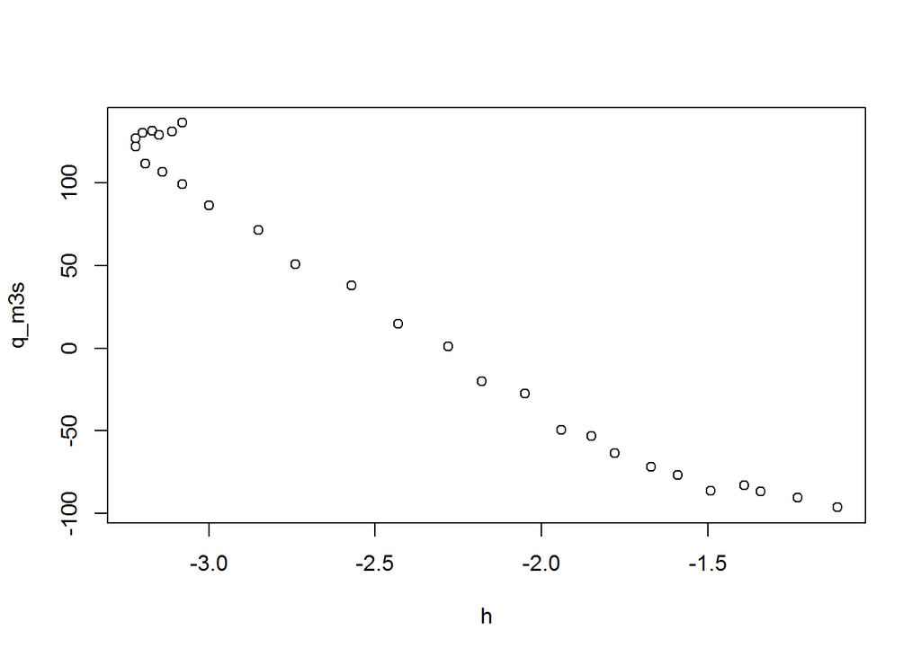

```r
plot(q_m3s ~ h, hs1)
```

### Another method

I’m not thrilled with the breakpoint function, although it might work as a last resort.

Trying now the changepoint package.

```r
install.packages("changepoint")
library(changepoint)
?cpt.mean

cpt.mean(hs1$h)
```

```r
hs2 <- hswot %>%
  filter(site_no == 11313433) %>%
   transmute(datetime = datetime,
             q_m3s = q_va * 0.028317,
            w_m = stream_wdth_va / 3.28084,
            logQ = log(q_m3s),
            logW = log(w_m),
            h = stage_va,
            xs = site_no,
            xsname = station_nm) %>%
  filter(!is.na(h))
cpt1 <- cpt.mean(hs2$h, class = FALSE)

cpt1
```

```
##        cpt conf.value
##        356          1
```

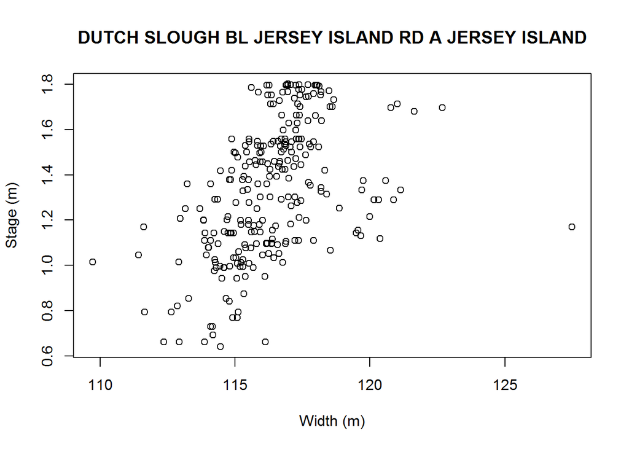

```r
cpt2 <- cpt.mean(na.omit(hs2$h), method = "BinSeg", Q = 1)

plothw(11313433)
```

Computing these like I did with the breakpoints package.

```r
cpstat <- function(x, ...) {
  cp <- cpt.mean(x, method = "BinSeg", Q = 1, ...)
  out <- cp@pen.value.full
  out
}

cstats <- xsdat %>%
  filter(n > 20) %>%
  group_by(xs, xsname) %>%
  summarize(cpstat = cpstat(h_m)) %>%
  ungroup() %>%
  mutate(xs = as.character(xs)) %>%
  arrange(desc(cpstat))

head(cstats)
```

```
## # A tibble: 6 × 3
##        xs                                            xsname   cpstat
##     <chr>                                             <chr>    <dbl>
## 1 7263605 Fourche Creek at Lindsey St. E of Little Rock, AR 921768.8
## 2 4232730                 SENECA RIVER NEAR SENECA FALLS NY 354288.6
## 3 1047150                Kennebec River near Madison, Maine 283009.3
## 4 4231600 GENESEE RIVER AT FORD STREET BRIDGE, ROCHESTER NY 218487.1
## 5 4247000                       ONEIDA RIVER NEAR EUCLID NY 212447.2
## 6 4240508   SENECA R (DS ONONDAGA OUTLET) NEAR LIVERPOOL NY 117224.5
```

```r
summary(bstats$brstat)
```

```
##    Min. 1st Qu.  Median    Mean 3rd Qu.    Max.
##  -3.000  -3.000  -3.000  -1.487  -3.000 110.700
```

```r
plothw(cstats$xs[i])

i <- i + 1
```